# Практика 37 · Жорсткість і сплайн

## 9. Границя: натуральний кубічний сплайн

Головний результат другої частини. Мінімізація ‖γ‖² — це насправді мінімізація ∫g″(x)²dx, тобто пошук **найменш вигнутої** кривої крізь точки. А функція, яка проходить крізь задані точки й мінімізує цей інтеграл, давно відома з чисельних методів: це **натуральний кубічний сплайн**.

Отже теорема звучить так: наші моделі мінімальної норми при K → ∞ збігаються до натурального кубічного сплайна. `scipy` вміє будувати його однією командою — звіримось.

```python
from scipy.interpolate import CubicSpline

сплайн = CubicSpline(X_ДАНІ, Y_ДАНІ, bc_type="natural")
сітка_порівняння = np.linspace(ЛІВА_МЕЖА, ПРАВА_МЕЖА, 401)
значення_сплайна = сплайн(сітка_порівняння)

rng = np.random.default_rng(77)
K_ДЛЯ_ЗБІЖНОСТІ = [4, 8, 16, 32, 64, 128, 256, 512]
розбіжності = []

print(f"{'K':>5} {'p':>5} {'макс. розбіжність зі сплайном':>32} {'похибка проти параболи':>25}")
for K in K_ДЛЯ_ЗБІЖНОСТІ:
    по_розкладах, похибки = [], []
    for _ in range(9):          # медіана по кількох розкладах вузлів
        вузли = np.sort(rng.uniform(ЛІВА_МЕЖА, ПРАВА_МЕЖА, K))
        коеф = навчити(вузли)
        по_розкладах.append(np.max(np.abs(прогноз(коеф, вузли, сітка_порівняння) - значення_сплайна)))
        похибки.append(похибка_проти_істини(коеф, вузли))
    розбіжності.append(np.median(по_розкладах))
    print(f"{K:>5} {K + 2:>5} {np.median(по_розкладах):32.4f} {np.median(похибки):25.4f}")

похибка_сплайна = np.mean(np.abs(значення_сплайна - істинна_функція(сітка_порівняння)))
print(f"\nпохибка самого сплайна проти параболи: {похибка_сплайна:.4f}")

assert розбіжності[-1] < 0.5, "модель не зійшлася до сплайна!"
assert розбіжності[-1] < розбіжності[0] / 5, "розбіжність мала помітно спадати!"
print("\n✅ розбіжність зі сплайном упала з "
      f"{розбіжності[0]:.2f} до {розбіжності[-1]:.3f} — моделі злилися")
```

```
    K     p    макс. розбіжність зі сплайном    похибка проти параболи
    4     6                           4.9011                    1.4139
    8    10                           2.7348                    0.8919
   16    18                           0.8405                    0.2960
   32    34                           0.6386                    0.2224
   64    66                           0.2404                    0.1688
  128   130                           0.3301                    0.1566
  256   258                           0.1718                    0.1480
  512   514                           0.1741                    0.1303

похибка самого сплайна проти параболи: 0.1330

✅ розбіжність зі сплайном упала з 4.90 до 0.174 — моделі злилися
```

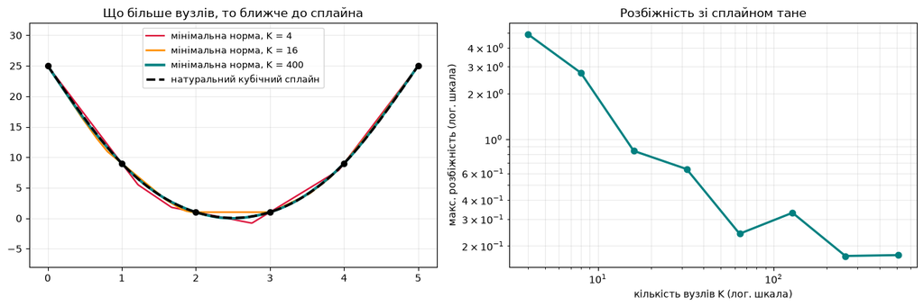

[output not shown]

```python
fig, (ліва, права) = plt.subplots(1, 2, figsize=(13, 4.4))

rng = np.random.default_rng(77)
for K, колір, товщина in [(4, "crimson", 1.6), (16, "darkorange", 1.8), (400, "teal", 2.6)]:
    вузли = np.sort(rng.uniform(ЛІВА_МЕЖА, ПРАВА_МЕЖА, K))
    коеф = навчити(вузли)
    ліва.plot(сітка_порівняння, прогноз(коеф, вузли, сітка_порівняння), lw=товщина,
              color=колір, label=f"мінімальна норма, K = {K}")
ліва.plot(сітка_порівняння, значення_сплайна, color="black", ls="--", lw=2.4,
          label="натуральний кубічний сплайн")
ліва.scatter(X_ДАНІ, Y_ДАНІ, s=32, color="black", zorder=4)
ліва.set_ylim(-8, 32)
ліва.set_title("Що більше вузлів, то ближче до сплайна"); ліва.legend(fontsize=9)
ліва.grid(alpha=.25)

права.plot(K_ДЛЯ_ЗБІЖНОСТІ, розбіжності, marker="o", lw=2.2, color="teal")
права.set_xscale("log"); права.set_yscale("log")
права.set_xlabel("кількість вузлів K (лог. шкала)")
права.set_ylabel("макс. розбіжність (лог. шкала)")
права.set_title("Розбіжність зі сплайном тане"); права.grid(alpha=.25, which="both")

plt.tight_layout(); plt.show()

print("Модель із сотнями параметрів на шести точках даних робить рівно те саме,")
print("що робить сплайн — давно вивчений, гарантовано розумний інтерполятор.")
print("Ось тут подвійний спуск і перестає бути парадоксом: уся загадка зводиться")
print("до того, що кубічний сплайн наближає параболу краще, ніж ламана з чотирьох сегментів.")
```

## 💻 Завдання

### 🟢 Рівень 1 — разом

1. Заміни параболу на іншу гладку функцію (наприклад, `np.sin(x)` на відрізку [0, 5]). Чи лишається пік на порозі? Чи так само модель збігається до сплайна?
2. Додай до `Y_ДАНІ` дрібний шум і перебудуй розділ 6. Що змінилось у медіані, а що — у хвості?

### 🟡 Рівень 2 — самостійно

1. Зроби вузли **рівномірними** замість випадкових (`np.linspace`). Куди подівся важкий хвіст на порозі й чому? Це і є відповідь на питання, що саме робить модель жорсткою.
2. Побудуй залежність похибки від кількості точок даних N (при фіксованому K = 20). Де тепер стоїть поріг?

### 🔴 Рівень 3 — виклик

1. Реалізуй мінімізацію ∫g″(x)²dx напряму — через дискретну другу похідну на щільній сітці й `scipy.optimize` — і покажи, що результат збігається з нашим розвʼязком мінімальної норми при великому K.
2. Замість базису ½·|x − t| візьми базис із гладких хвиль (як у практиці 36). Що тепер означає «мінімальна норма»? До якої кривої збігається модель? Це і є ілюстрація індуктивного зміщення архітектури.

## 🧪 Самоперевірка

**1. Чому α і β не входять у норму, яку ми мінімізуємо?**

**відповідь**

Пряма α + βx — «безкоштовна» частина моделі: вона не має зламів і не робить криву вигнутою. Мінімізуємо ми, по суті, вигнутість (∫g″²), а в неї пряма не вносить нічого. Штрафувати α і β означало б без потреби притискати модель до нуля.

**2. На порозі отримали похибку 0.9, а сума залишків — 10⁻¹³. Модель хороша?**

**відповідь**

Ні. Нульові залишки означають лише, що крива пройшла крізь шість точок — вони нічого не кажуть про те, що діється між точками. У розділі 5 ми бачили криві з нульовими залишками й розмахом у сотні одиниць. Дивитись треба на похибку проти істини, а не на залишки.

**3. Чому середню помилку на порозі рахувати безглуздо?**

**відповідь**

Бо теоретично вона нескінченна: імовірність невдалого розкладу вузлів пропорційна ε, а похибка в цьому випадку росте як 1/ε, і сума таких внесків розбігається. На практиці це видно як число, яке щоразу визначається одним найгіршим розкладом і не стабілізується. Тому дивляться на медіану й процентилі.